# Cardio Good Fitness

### Jaideep Majumdar

#### This is the first project in this course. The goal of this project is to do exploratory data analysis with the cardio good fitness data

```python
import pandas as pd
import numpy as np
import seaborn as sns
import matplotlib.pyplot as plt
```

```python
sns.set(color_codes=True)
%matplotlib inline
```

### Let's load up the data for the project

```python
cgf_data = pd.read_csv('CardioGoodFitness.csv')
```

### Let's learn a bit about the shape of the data, the columns, the number of rows, and some statistics

```python
cgf_data.shape
```

```
(180, 9)
```

##### The above result tells me that the dataframe has 180 records and the data is in 9 columns

```python
cgf_data.columns     # This will tell me the list of columns in the dataframe
```

```
Index(['Product', 'Age', 'Gender', 'Education', 'MaritalStatus', 'Usage',
       'Fitness', 'Income', 'Miles'],
      dtype='object')
```

```python
cgf_data.dtypes     # This tells me about the type of data in the various columns
```

```
Product          object
Age               int64
Gender           object
Education         int64
MaritalStatus    object
Usage             int64
Fitness           int64
Income            int64
Miles             int64
dtype: object
```

```python
cgf_data.describe()  # Let's get an idea of the nature of data in the sample and the kind of data distribution
```

|  | Age | Education | Usage | Fitness | Income | Miles |
| --- | --- | --- | --- | --- | --- | --- |
| count | 180.000000 | 180.000000 | 180.000000 | 180.000000 | 180.000000 | 180.000000 |
| mean | 28.788889 | 15.572222 | 3.455556 | 3.311111 | 53719.577778 | 103.194444 |
| std | 6.943498 | 1.617055 | 1.084797 | 0.958869 | 16506.684226 | 51.863605 |
| min | 18.000000 | 12.000000 | 2.000000 | 1.000000 | 29562.000000 | 21.000000 |
| 25% | 24.000000 | 14.000000 | 3.000000 | 3.000000 | 44058.750000 | 66.000000 |
| 50% | 26.000000 | 16.000000 | 3.000000 | 3.000000 | 50596.500000 | 94.000000 |
| 75% | 33.000000 | 16.000000 | 4.000000 | 4.000000 | 58668.000000 | 114.750000 |
| max | 50.000000 | 21.000000 | 7.000000 | 5.000000 | 104581.000000 | 360.000000 |

### The description of the data (above) tells us the following

- There are 180 records in the dataset.
- The minimum age of people in the sample in the sample is 18 and the max age is 50. So we are looking ta an adult population that is not too old.
- The mean and median for age is very close to each other, so this is expected to be close to a normal distribution with a slight right skew.
- The minimum number of years of education is 12 years and maximum is 21 years. So we are looking at a population that has at least completed high school and at the other end probably completed doctorate degrees.
- The income level ranges from 29,562 to 104,581, so we are looking at a wide disparity of income levels.
- The miles walked/run by the people ranges from 21 miles to 360 miles, so there is a very wide spread of cardio exercises conducted by the people in this sample.

```python
cgf_data.head(10)  # Display the first 10 records from the data to get an idea of what it looks like
```

|  | Product | Age | Gender | Education | MaritalStatus | Usage | Fitness | Income | Miles |
| --- | --- | --- | --- | --- | --- | --- | --- | --- | --- |
| 0 | TM195 | 18 | Male | 14 | Single | 3 | 4 | 29562 | 112 |
| 1 | TM195 | 19 | Male | 15 | Single | 2 | 3 | 31836 | 75 |
| 2 | TM195 | 19 | Female | 14 | Partnered | 4 | 3 | 30699 | 66 |
| 3 | TM195 | 19 | Male | 12 | Single | 3 | 3 | 32973 | 85 |
| 4 | TM195 | 20 | Male | 13 | Partnered | 4 | 2 | 35247 | 47 |
| 5 | TM195 | 20 | Female | 14 | Partnered | 3 | 3 | 32973 | 66 |
| 6 | TM195 | 21 | Female | 14 | Partnered | 3 | 3 | 35247 | 75 |
| 7 | TM195 | 21 | Male | 13 | Single | 3 | 3 | 32973 | 85 |
| 8 | TM195 | 21 | Male | 15 | Single | 5 | 4 | 35247 | 141 |
| 9 | TM195 | 21 | Female | 15 | Partnered | 2 | 3 | 37521 | 85 |

# Univariate data analysis

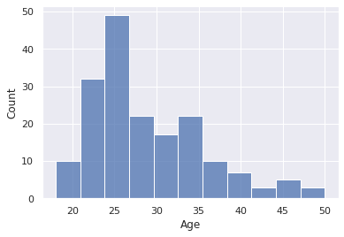

```python
sns.histplot(cgf_data.Age);   # Find out the age distribution of the people in the sample
```

##### The distribution above shows a right-skewed curve with the bulk of the candidates being in the mid-20s in age. Fewer people are in the 40s in this sample, so the dataset represents younger adults. Perhaps his corresponds to people who are more likely to be using cardio equipments for exercise. The distirbution corresponds to the median of 26 and mean of about 29.

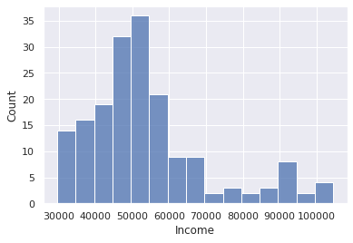

```python
sns.histplot(cgf_data.Income);    # Let's understand the income distribution of the sample using a histogram
```

##### The distribution bove shows income varying from 30,000 to about 105,000 with the mode being in the 50,000 - 55,000 range. This agrees with the mean being about 54,000 and median being about 51,000.

##### The higher earners are very few in number so the distribution has a strong right skew.

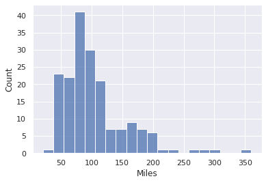

```python
sns.histplot(cgf_data.Miles);    # Use a histogram to get the total number of miles run by people in the sample
```

##### The distribution above has a strong right skew with a long tail, although most of the values lie in the smaller numbers. The median is 94 miles, which means that more than half the population runs less than a 100 miles. In fact, 75% of the population runs less than 114 miles, with an interquartile range of 48 miles. So people running 200 miles or more can be considered outliers.

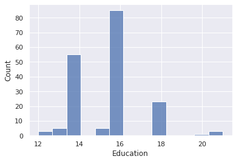

```python
sns.histplot(cgf_data.Education);   # Study the education level of the people in the sample.
```

##### The sample consists mostly of people who have had at least some college education (assuming 12 years represents High School education). The bulk of the people probably did 4-year college to have a Bachelor's degree. A lot fewer people in the sample had more education.

##### This tells us that the sample is a well-educated set of people, but not extremely pedantic. This will help identify the target population for a marketing campaign.

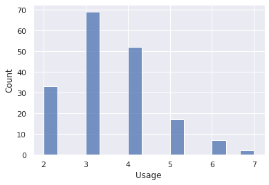

```python
sns.histplot(cgf_data.Usage);  # Use histogram to find out the usage of the products per week
```

##### Not suprising that the distribution is a normal distribution with a slight right skew. Most people use the cardio products 3 days a week. A majority of the population uses the devices 2-4 days a week.

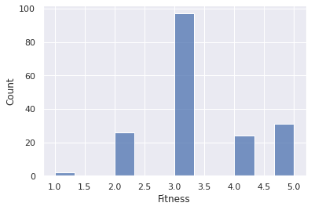

```python
sns.histplot(cgf_data.Fitness);  # Use a histogram to get the distribution of health conditions of the customers
```

##### As expected, the curve is a normal distribution with the bulk of the people in the sample having average health. The interesting observation is that people with a health of 5 (very good) make the second highest population. Also there are very few people who reported having very poor health.

##### This result can actually be used in marketing campaigns to extol the virtues of using the cardio products for good health.

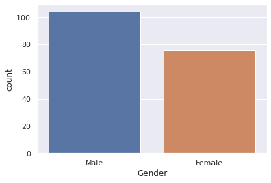

```python
 sns.countplot(data=cgf_data, x='Gender');
```

##### The countplot above showing the distribution of male and female shows that there are more than 100 male in the sample vs. less than 80 female in the sample.

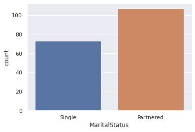

```python
sns.countplot(data=cgf_data, x='MaritalStatus');
```

##### The countplot above shows the distirbution of partnered vs. single people in the sample. The sample had more than a 100 partnered individuals and less mthan 80 singles.

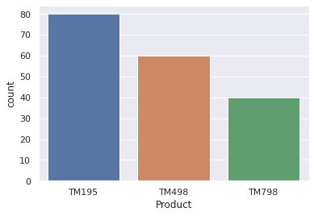

```python
sns.countplot(data=cgf_data, x='Product'); # Use countplot to identify the products and how popular they are
```

##### The countplot shows that there are 3 models in the dataset, The most ppopular one in this dataset if TM195, representing almost 80 of the 180 records in the dataset.

# Multivariate analysis for numeric data

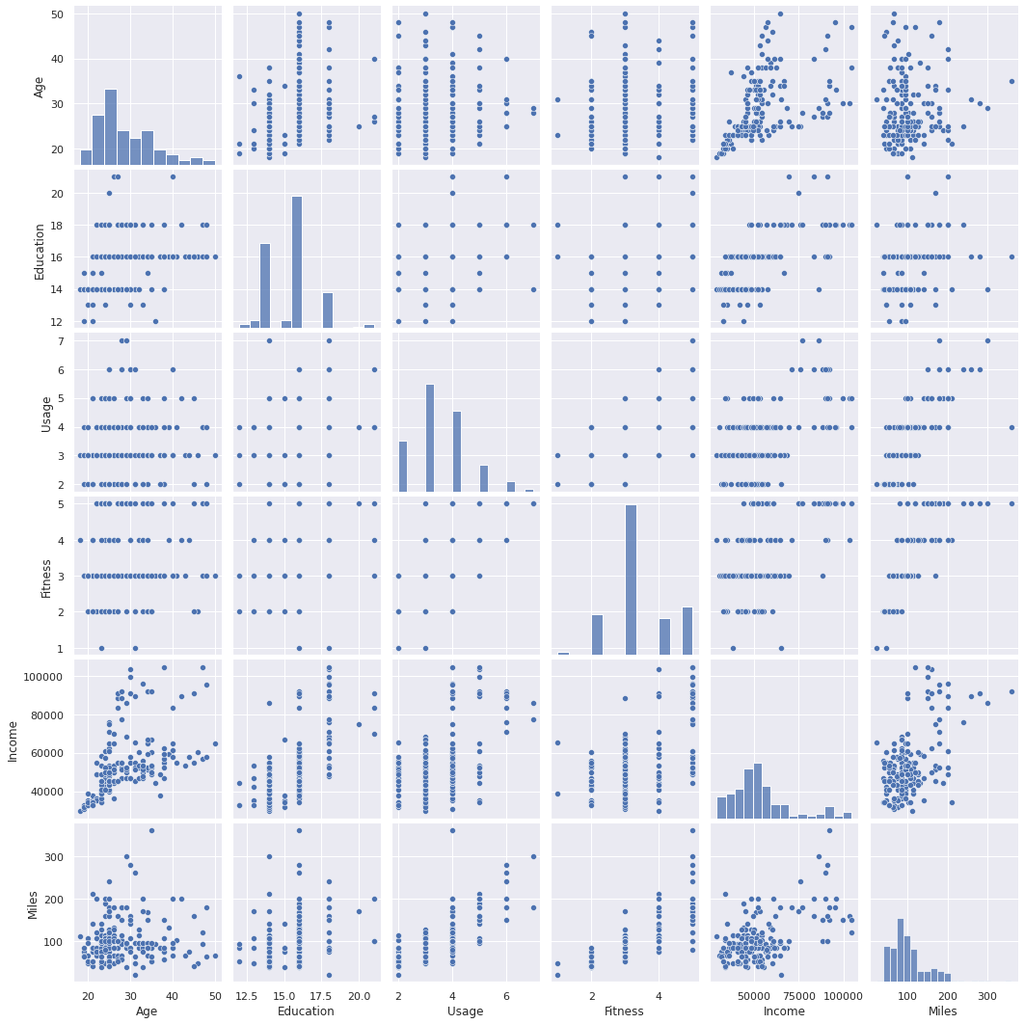

```python
sns.pairplot(cgf_data);   # Let's study the correlation between numeric data using pairplot
```

##### The pairplot above shows a few interesting things

- The histogram for education, usage, and fitness are fairly close to normal distribution, which is not unexpected.
- The scatterplot between income and miles shows a strong correlation between income and miles - higher earners tend to walk/run more miles using the equipment.
- There is also a strong correlation between age and income -- income increases as people get older. This is not surprising. However, we see some people whose income rises much faster than others, and then there are those whose income increases a lot slower with age. This shows up as a bifurcation in the scatterplot.
- There is an interesting correlation between income and usage - the higher earners tend to use the equipment more often.
- But there is a strong correlation between income and fitness - higher income people tend to be fitter.
- There is a strong correlation between usage and miles, which makes sense. The more you use the equipment, the more miles you tend to run/walk.
- There is a strong correlation between usage and fitness - the more you use the equipment the fitter you are likely to be.
- There doesn't appear to be a strong correlation between education level and fitness.
- But there is a strong correlation between education and income level - the more educated you are, the more you are likely to earn.
- One surprising thing - there doesn't appear to be a strong correlation between age and usage, or age and fitness. This data combined with the other correlations shows that income and usage rather than age have a much stronger influence on a person's fitness.

### Confirmation of some the above observations using linear regression models

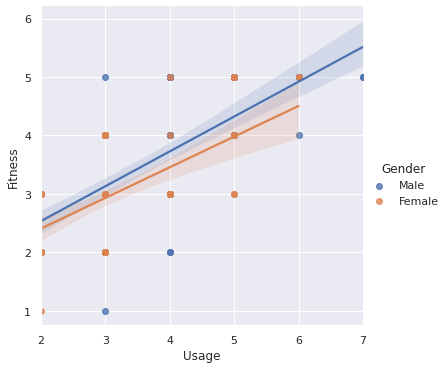

```python
sns.lmplot(y='Fitness', x='Usage', hue='Gender', data=cgf_data);
```

##### Linear regression model above shows a strong correlation between usage and fitness for both genders.

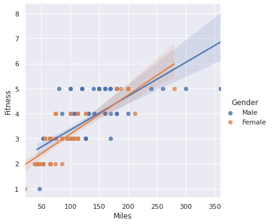

```python
sns.lmplot(y='Fitness', x='Miles', hue='Gender', data=cgf_data);
```

##### Linear regression model above shows a strong correlation between miles covered and fitness. Women appear to get a greater benefit than men.

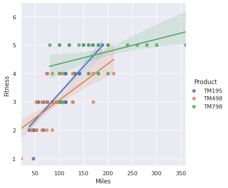

```python
sns.lmplot(data=cgf_data, y='Fitness', x='Miles', hue='Product'); # Find correlation between fitness and model
```

##### All three models show that there is a positive correlation between miles run and fitness. However, the TM195 appears to be the most effective of the three models - the more you use it, the more fit you get.

##### The interesting point is that the model TM798 appears to be used by people who are already very fit, and they tend to run a lot more miles on that equipment. The gain in fitness is not as sharp, but that it perhaps because the customers of TM798 started off being a lot more fit.

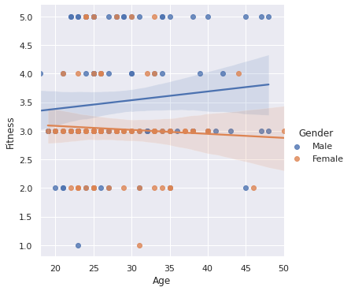

```python
sns.lmplot(y='Fitness', x='Age', hue='Gender', data=cgf_data);
```

##### Linear regression model above shows hardly any correlation between age and fitness level. This is true for both men and women.

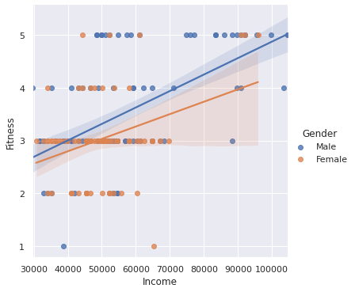

```python
sns.lmplot(y='Fitness', x='Income', hue='Gender', data=cgf_data);
```

##### Linear model above shows a strong correlation between income and fitness for men. For women, although there is a positive correlation, there is a greater margin of error in the line fit, showing a somewhat weaker correlation.

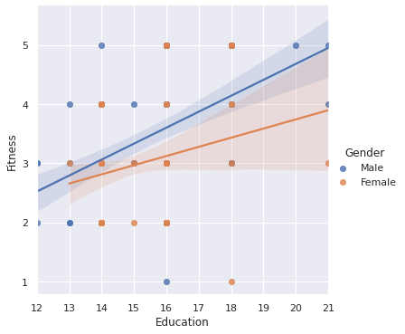

```python
sns.lmplot(y='Fitness', x='Education', hue='Gender', data=cgf_data);
```

##### The linear regression model above shows a positive relationship between level of education and fitness level. This insight can be used to plan marketing campaigns.

# Multi-variate analysis continued for categorical data...

##### Continuing to dig into deeper insights into product preferences based on various attributes of the people in the sample

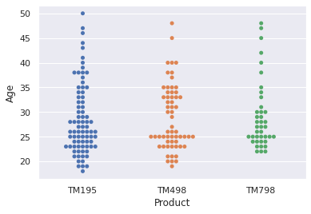

```python
sns.swarmplot(data=cgf_data, x='Product', y='Age'); # Find age distribution of customers of the products
```

##### The swarmplot helps me see the age distribution of the customers of the different products. There isn't a lot to choose here since there is a similar age distribution for customers of each of the three products.

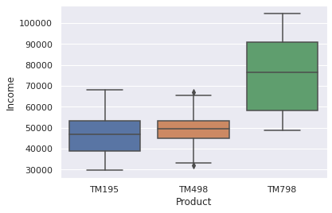

```python
sns.boxplot(data=cgf_data, x='Product', y='Income'); # Try to see if there is difference in income level
```

##### This gets interesting because we start to see some differentiation. Whereas the products TM195 and TM498 are favored by people in the lower income group (up to 70,000 in income), the product TM798 is favored by the higher income individuals.

##### Next I want to explore any gender bias towards any of the products...

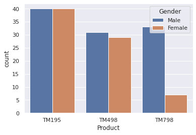

```python
sns.countplot(data=cgf_data, x='Product', hue='Gender');  # Explore any gender bias towards any of the products
```

##### Another interesting insight. For TM195 and TM498, people from both sexes appear to be using the product equally. However, for TM798, there is clearly much greater usage by men than by women.

##### Need to explore why is that. Is it because TM798 is harder to use, or is it something related to income? I have seen that people with higher income use TM798 more often. Let me look at the income distribution across men and women in this sample.

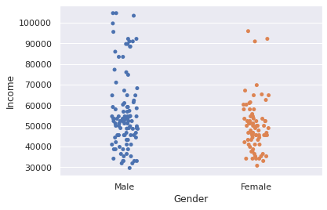

```python
sns.stripplot(data=cgf_data, x='Gender', y='Income', jitter=True);  # Explore income across gender using stripplot
```

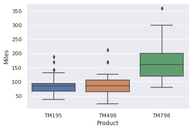

```python
sns.boxplot(data=cgf_data, x='Product', y='Miles'); # Explore if people run different distances using different products
```

##### This shows that people who use the TM798 model run a lot more miles than people in the other category.

##### We had previously seen that the fewest number of people in the sample use TM798. We also saw that people who use TM798 are in general much fitter than people using the other models.

##### The combination makes me conclude that TM798 is a professional grade cardio system that is used by athletes for training. That explains why there are fewer of that product, yet the customers run more miles and are fitter.

##### We have also seen that women don't prefer TM798, hence it is the equipment of choice for male athletes.

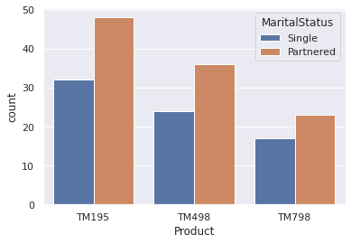

```python
sns.countplot(data=cgf_data, x='Product', hue='MaritalStatus'); # Preference of product for partnered vs. single?
```

##### No, there is no preference for any product based on partnered/single status. We see similar single to partnered ratio for each of the products.

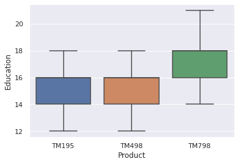

```python
sns.boxplot(data=cgf_data, x='Product', y='Education'); # Education level of people using different products?
```

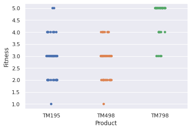

```python
sns.stripplot(data=cgf_data, x='Product', y='Fitness'); #ind fitness levels of people using different products
```

##### For the products TM195 and TM498, it is a normal distirbution of fitness level. However, people using TM798 tend to have high fitness level with the mode being a level of 5.

# Insights and Recommendations

## Insights

##### The various insights have been documented alongside the analysis. They are summarized here

- There are 3 products in the dataset.
- There are 180 people in the dataset with about 100 men and 80 women in the sample.
- The age of the people in the sample ranges from 18 to 50, so they are all adults who are not too old to use cardio equipments.
- There is a wide range of income levels, education levels, and fitness levels within the sample population.
- All histograms for age, income level, education level, fitness level, usage, and miles show a normal distirbution, with some of them having a skew to the right.

-

- The products TM195 and TM498 have customers with similar demographics -- People with education level ranging from High School to college, with 25-75% lying between 14-16 years. -- Lower to middle income with median closer to 45,000 -- About average fitness conditions with median and mode at 3 -- Equally preferred by men and women.

-

- The product *TM798* has a different customer base -- People who have higher education levels with at least 14 years of education, and the 25-75% lying between 16-18 years. -- They tend to have higher income levels with median income arond 80,000. -- Customers tend to have very high fitness level with mode being level 5. -- Men prefer TM798 much more than women. The market is clearly missing out on women customers. -- It is likely that the customers of TM798 are high-earning male athletes.

-

- For all three products, age doesn't make a difference if people's preferences.
- For all three products, people's partnered/single status does not affect their preference.

-

Some product-independent insights from the data are

- Using the products more often in a week increases fitness levels, for both men and women.
- The more miles you run, the better is the fitness level.
- Both of the above points can be utilized to market the cardio products as a means of improving fitness levels.
- People with higher education and income levels also tend to have higher fitness levels. This can create opportunities to sell more high-end equipments.

## Recommendations

##### Some recommendations to target new customers

- Identify what is causing poor adoption of TM798 with women and address it. Conduct a survey to identify reasons.
- If it is a product issue that makes it harder for women to use it, then provide feedback to the makers of TM798.
- If it is an image problem, then design advertisement to improve adoption of the product among women.
- Knowing that TM195 AND TM498 is more popular among lower income individuals but make up a greater volume of the sales, use promotional offers and other discounts to increase their volumes further.
- Given the clear relationship between the use of the products and fitness levels of individuals, create advertisements extolling the health benefits of the products to drive more sales. Use data to encourage people to buy.
- Given that customers' income levels increase with age, create targeted advertisements for people in the 40-50 year range to try to sell more products. That population will tend to have the most expendable income and will also be more conscious about health given that they are getting older.